# POLS 2972Q

Quantitative Analysis in Political Science

Lecture 13 |

Survey Research and Exploring One Variable at at Time

## Today’s Question

Looking at the histogram of a variable, we can get a sense of:

A. the distribution of the variable

B. the mean of the variable

C. the spread of the variable

D. all of the above

## Plan for Today

- Sample vs. Population
  - Representative samples
  - Random Sampling
  - Random Treatment Assignment vs. Random Sampling
- Exploring One Variable At a Time - Table of frequencies
  - Table of proportions
  - Histogram
  - Descriptive Statistics: mean, median, standard deviation, and variance

## Sample vs. Population

- We often want to know the characteristics of a large **population** such as the residents of a country
- Yet collecting data from every individual in the population is either prohibitively expensive or simply infeasible
- In the US, we try to collect data from each individual every ten years
  - The 2020 census cost $14.2 billion, approximately (population at that time was around 331 million)
  - This is not feasible for research purposes!
- We use surveys to collect data from a small subset of observations in order to understand the population
- The subset of individuals chosen for study is called a sample

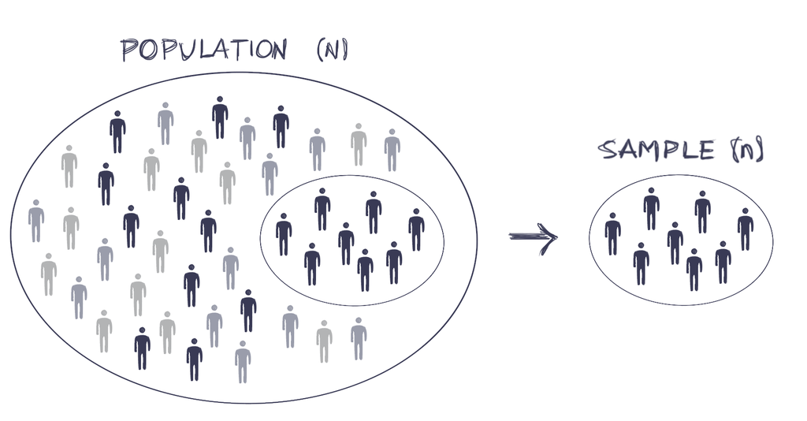

- In the US, researchers typically survey only about 1,000 people to infer the characteristics of more than 200 million adult citizens (n=1,000, N=200 million)

## Representative Samples

- In survey research, it is vital for the sample to be representative of the population of interest
- A representative sample accurately reflects the characteristics of the population from which it is drawn, that is, characteristics appear in the sample in similar proportions as in the population as a whole
- If the sample is not representative, our inferences regarding the population characteristics based on the sample will be wrong
- Are you a representative sample of U.S. residents?
- Are you a representative sample of UConn students?
- Are you a representative sample of UConn POLS majors?
- Are you a representative sample of POLS 2972Q students?
- What would be the best way to draw a representative sample of UConn students?
  - Using random sampling
  - Get the list of all UConn students and select n students at random

## Random Sampling

- The best way to draw a representative sample is to select individuals at random from the population
  - This procedure is called random sampling
- **Random sampling** makes the sample and the target population on average identical to each other in all observed and unobserved characteristics
- Random sampling ensures that the sample is representative of the target population
  - Enabling us to infer valid population characteristics from the sample

## Random Treatment vs. Random Sampling

- They both use a random process but they refers to two very different concepts
- **Random treatment assignment** means that treatment is assigned at random
  - Makes treatment and control groups comparable
  - Enables us to produce valid estimates of the average treatment effect (using diffs-in-means estimator)
- **Random sampling** means that individuals are selected at random from the population into the sample
  - Makes sample representative of the population
  - Enables us to infer valid population characteristics from the sample

## Exploring One Varible at a Time

- Suppose we have collected data from a sample, now what?
- To understand the content and distribution of each variable we can:
  - Create a table of frequencies
  - Create a table of proportions
  - Create a histogram
  - Compute descriptive statistics
- Let’s return to the voting experiment
  - Data collected from a sample of registered voters in the state of Michigan

## The `voting` dataset

- Unit of observation: registered voters
- Description of variables:

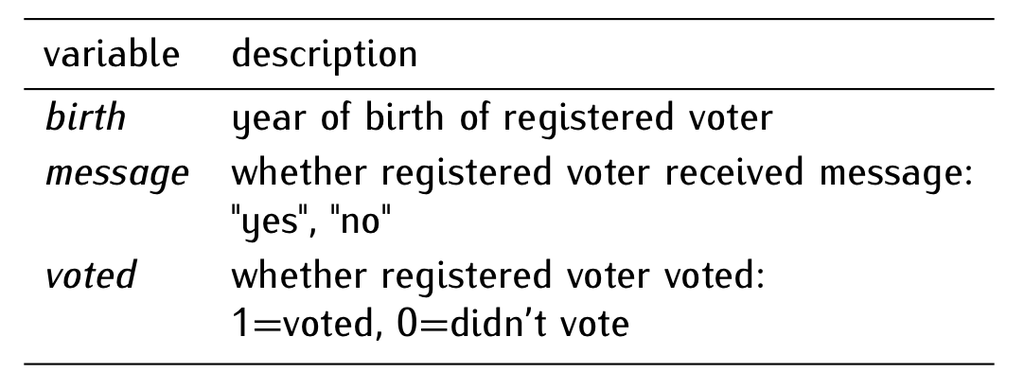

## Setting up the Data

```r
#set the working directory
#setwd("~/Dropbox/Schools/UCONN/Fall 2025/POLS 2972Q/Week 7/Lecture 1")

#load the data
voting <- read.csv("voting.csv")

#look at the data
head(voting)
```

```
  birth message voted
1  1981      no     0
2  1959      no     1
3  1956      no     1
4  1939     yes     1
5  1968      no     0
6  1967      no     0
```

## Table of Frequencies

- The **frequency table** of a variable shows the values the variable takes and the number of times each value appears in the variable
- We will use the R function: `table()`

```r
table(voting$voted)
```

```
     0      1
158276  71168
```

- How do we interpret this?

## Table of Proportions

- The **table of proportions** of a variable shows the proportion of observations that take each value in the variable
- The proportions in the table should add up to 1
- We will use the R function: `prop.table(table())`

```r
prop.table(table(voting$voted))
```

```
        0         1
0.6898241 0.3101759
```

- How do we interpret this?

## Histogram

- The **histogram** of a variable is the visual representation of its distribution through bins of different heights
- The position of the bins along the x-axis indicate the interval of values
- The height of the bins indicate the frequency (or count) of the interval of values
- R functions:
  - `ggplot()`

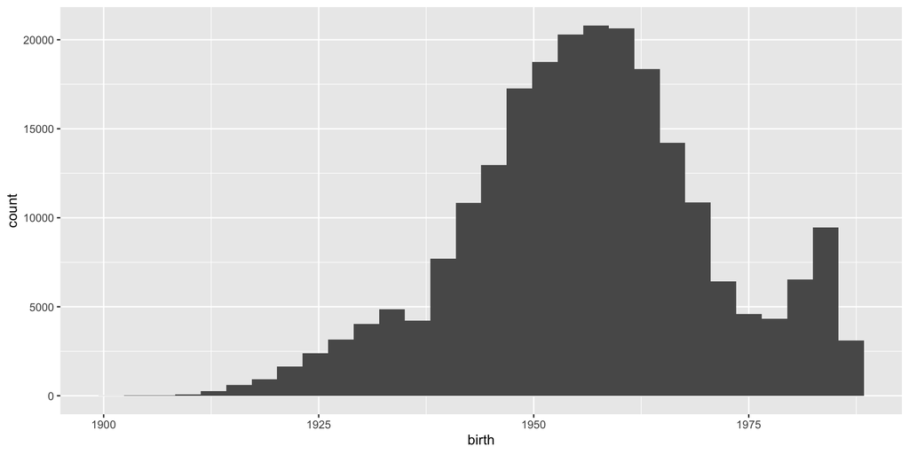

```r
ggplot(data = voting) +
  geom_histogram(mapping = aes(x = birth))
```

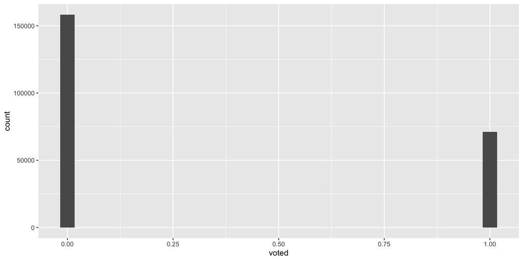

```r
ggplot(data = voting) +
  geom_histogram(mapping = aes(x = voted))
```

- base R

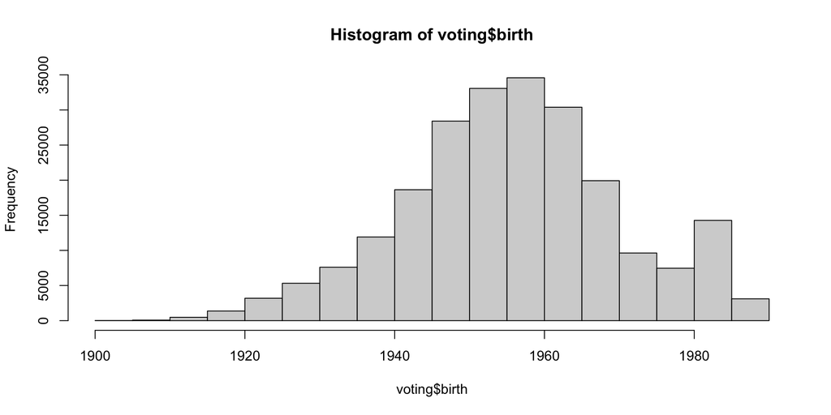

```r
hist(voting$birth)
```

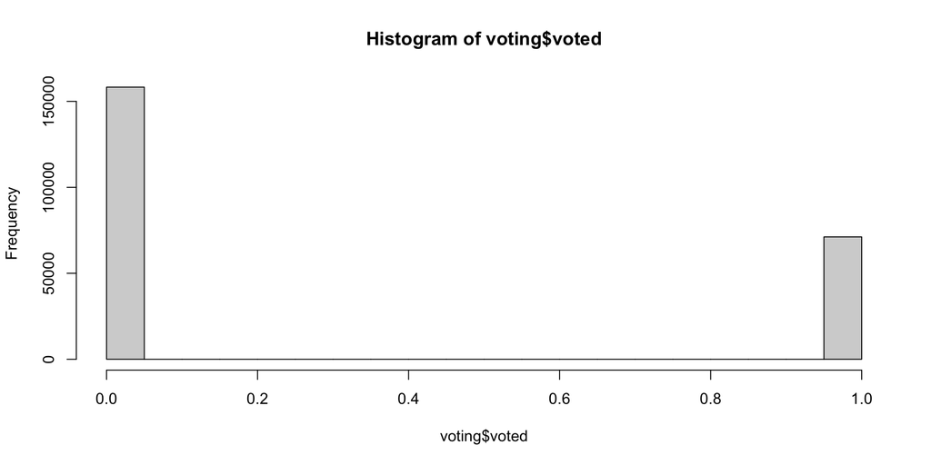

```r
hist(voting$voted)
```

- How do we interpret this?

## Descriptive Statistics

- The **descriptive statistics** of a variable numerically summarize the main characteristics of its distribution
- Measures of centrality (center of distribution)
  - Mean
  - Median
- Measures of spread (amount of variation from center)
  - Standard deviation
  - Variance

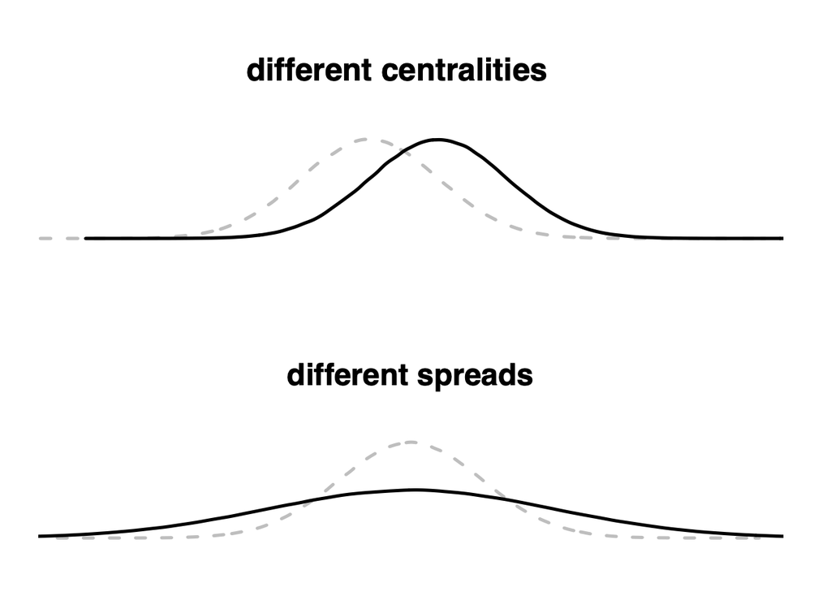

## Mean

- As we already saw, the mean of a variable equals the sum of the values across all observations divided by the total number of observations
- What is the function in R?

```r
mean(voting$birth)
```

```
[1] 1956.18
```

```r
mean(voting$voted)
```

```
[1] 0.3101759
```

## Median

- The median of a variable is the value at the midpoint of the distribution that divides the data into two equal-size groups
- When the variable contains an odd number of observations, the median is the middle value of the distribution
- When the variable contains an even number of observations, the median is the average of the two middle values
- Example: if X = {10, 4, 6, 8, 22}, what is the median of X?
  - First, we need to sort the values of X in ascending order (as they would be in the distribution): {4, 6, 8, 10, 22}
    - The value in the middle of the distribution is 8 so the **median** is 8
- R function:

```r
median(voting$birth)
```

```
[1] 1956
```

```r
median(voting$voted)
```

```
[1] 0
```

## Standard Deviation

- The **standard deviation** of a variable is a measure of the spread of its distribution

$sd(X) = \sqrt{\frac{\sum_{i=1}^n(X_i-\bar{X})^2}{n}}$

- Where
  - $sd(X)$ stands for the standard deviation of X
  - $X_i$ is a particular observation of X
  - $\bar{X}$ stands for the mean of X
  - $n$ is the total number of observations in the variable
  - $\sum_{i=1}^n(X_i-\bar{X})^2$ means the sum of all $(X_i - \bar{X})^2$ from i = 1 to i = n
- The **standard deviation** of a variable measures the average distance of the observations to the mean
- The larger the standard deviation, the flatter the distribution
- Of the following two distributions, which one has a larger standard deviation, the dashed distribution or the solid one?

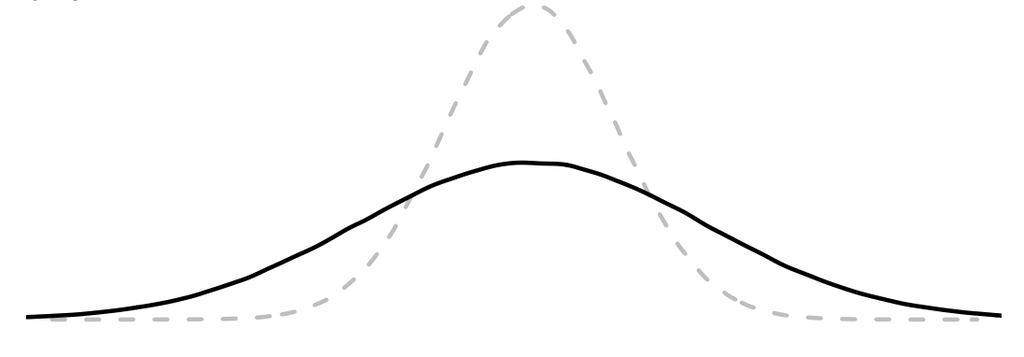

- The standard deviation of a variable gives us a sense of the range of the data, especially when dealing with bell-shaped distributions known as normal distributions
- In normal distributions, 95% of the observations fall within two standard deviations from the mean

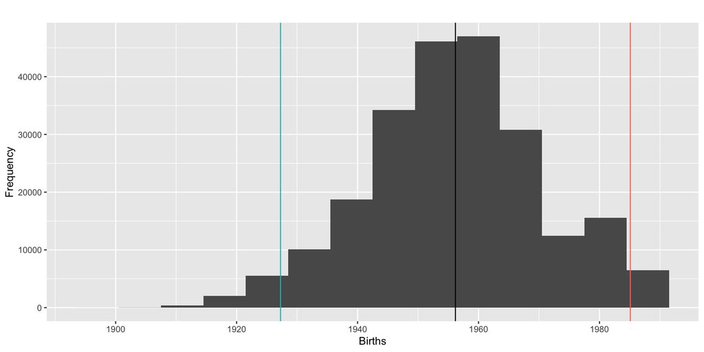

```r
ggplot(data = voting) +
  geom_histogram(mapping = aes(x = birth), binwidth = 7) +
  geom_vline(mapping = aes(xintercept = mean(birth))) +
  geom_vline(mapping = aes(xintercept = mean(birth) - 2 * sd(birth), color = "red")) +
  geom_vline(mapping = aes(xintercept = mean(birth) + 2 * sd(birth), color = "green")) +
  labs(title = "",
       y = "Frequency",
       x = "Births") +
  scale_x_continuous(breaks = seq(1900, 2020, by = 20)) +
  theme(legend.position = "none")
```

- R function

```r
sd(voting$birth)
```

```
[1] 14.46019
```

- If birth were normally distributed, about 95% of the register voters in the voting experiment would have been born between 1927 and 1985
  - $\bar{X} - 2 \times sd(X)$ = 1956 - 2 $\times$ 14.5 = 1927
  - $\bar{X} + 2 \times sd(X)$ = 1956 + 2 $\times$ 14.5 = 1985

## Variance

- Another measure of the spread of the distribution
- The **variance** of a variable is simply the square of the standard deviation

$var(X) = sd(X)^2$

- Where
  - $var(X)$ stands for the variance of X
  - $sd(X)$ stands for the standard deviation of X
- R function

```r
var(voting$birth)
```

```
[1] 209.0971
```

- Alternatively

```r
sd(voting$birth)^2
```

```
[1] 209.0971
```

- We are usually better off using standard deviations as our measure of spread, as they are easier to interpret because they are in the same unit of measurement as the variable
- If we are given a variance, we can compute the standard deviation by taking the square root of the variance. R function to compute a square root?

```r
sd(voting$birth)
```

```
[1] 14.46019
```

```r
var(voting$birth)
```

```
[1] 209.0971
```

```r
sqrt(var(voting$birth))
```

```
[1] 14.46019
```